# HM4_Jordan

## Read in the file Popular_Baby_Names.csv

```python
import pandas as pd
popular_babynames = pd.read_csv("Popular_Baby_Names.csv")
popular_babynames.head()
```

|  | Year of Birth | Gender | Ethnicity | Child's First Name | Count | Rank |
| --- | --- | --- | --- | --- | --- | --- |
| 0 | 2016 | FEMALE | ASIAN AND PACIFIC ISLANDER | Olivia | 172 | 1 |
| 1 | 2016 | FEMALE | ASIAN AND PACIFIC ISLANDER | Chloe | 112 | 2 |
| 2 | 2016 | FEMALE | ASIAN AND PACIFIC ISLANDER | Sophia | 104 | 3 |
| 3 | 2016 | FEMALE | ASIAN AND PACIFIC ISLANDER | Emily | 99 | 4 |
| 4 | 2016 | FEMALE | ASIAN AND PACIFIC ISLANDER | Emma | 99 | 4 |

## Print the shape and the first 10 rows to familiarize yourself with the data

```python
df = pd.DataFrame(popular_babynames)
print("Shape of the DataFrame:", df.shape)

rows = 10
print (f"First {rows} rows of the DataFrame:")
print (df.head(rows))
```

```
Shape of the DataFrame: (19418, 6)
First 10 rows of the DataFrame:
   Year of Birth  Gender                   Ethnicity Child's First Name  \
0           2016  FEMALE  ASIAN AND PACIFIC ISLANDER             Olivia
1           2016  FEMALE  ASIAN AND PACIFIC ISLANDER              Chloe
2           2016  FEMALE  ASIAN AND PACIFIC ISLANDER             Sophia
3           2016  FEMALE  ASIAN AND PACIFIC ISLANDER              Emily
4           2016  FEMALE  ASIAN AND PACIFIC ISLANDER               Emma
5           2016  FEMALE  ASIAN AND PACIFIC ISLANDER                Mia
6           2016  FEMALE  ASIAN AND PACIFIC ISLANDER          Charlotte
7           2016  FEMALE  ASIAN AND PACIFIC ISLANDER              Sarah
8           2016  FEMALE  ASIAN AND PACIFIC ISLANDER           Isabella
9           2016  FEMALE  ASIAN AND PACIFIC ISLANDER             Hannah

   Count  Rank
0    172     1
1    112     2
2    104     3
3     99     4
4     99     4
5     79     5
6     59     6
7     57     7
8     56     8
9     56     8
```

## Rename the "Year of Birth" & "Child's First Name" columns to remove the spaces and apostrophe. Explain why managing column names this way can be advantageous. The importance of renaming columns is to continue consistant patterns in code as well as naming conventions. I chose snake_case as it is my favorite way to reference code.

```python
df = df.rename(columns={'Year of Birth': 'Year_Of_Birth', "Child's First Name": 'Childs_First_Name'})
df.head()
```

|  | Year_Of_Birth | Gender | Ethnicity | Childs_First_Name | Count | Rank |
| --- | --- | --- | --- | --- | --- | --- |
| 0 | 2016 | FEMALE | ASIAN AND PACIFIC ISLANDER | Olivia | 172 | 1 |
| 1 | 2016 | FEMALE | ASIAN AND PACIFIC ISLANDER | Chloe | 112 | 2 |
| 2 | 2016 | FEMALE | ASIAN AND PACIFIC ISLANDER | Sophia | 104 | 3 |
| 3 | 2016 | FEMALE | ASIAN AND PACIFIC ISLANDER | Emily | 99 | 4 |
| 4 | 2016 | FEMALE | ASIAN AND PACIFIC ISLANDER | Emma | 99 | 4 |

## Print the data types and describe if they are appropriate for analysis or need to be converted to other types. If they need to be converted, perform the conversions. The data types listed as integers "Count" and "Rank" are appropriate data types as they represent numeric/integer values. Also "Gender", "Ethnicity" and "Childs_First_Name" are also appropriate as objects as they are represented as strings. I changed Year_Of_Birth from an Int to an Obj as we do not add years together.

```python
print("Data Types of the file Popular Baby Names are:")
print(df.dtypes)
print()
print("The Updated Data Types of the file Popular Baby Names are:")
df['Year_Of_Birth'] = df['Year_Of_Birth'].astype('object')
print(df.dtypes)
```

```
Data Types of the file Popular Baby Names are:
Year_Of_Birth         int64
Gender               object
Ethnicity            object
Childs_First_Name    object
Count                 int64
Rank                  int64
dtype: object

The Updated Data Types of the file Popular Baby Names are:
Year_Of_Birth        object
Gender               object
Ethnicity            object
Childs_First_Name    object
Count                 int64
Rank                  int64
dtype: object
```

## After reviewing the data, clean the data as you see appropriate. For this cleaning step, you do not need to show all your work or interim results as you examine the data, but you do need to show any commands you used to alter any of the data in the order you use them.

```python
#this definition combines duplications of ethnicity names that appear
def group_ethnicities(df):
    for index, row in df.iterrows():
        if 'ASIAN AND PACI' in row['Ethnicity']:
            df.loc[index, 'Ethnicity'] = 'ASIAN AND PACIFIC ISLANDER'
        elif 'BLACK NON HISP' in row['Ethnicity']:
            df.loc[index, 'Ethnicity'] = 'BLACK NON HISPANIC'
        elif 'WHITE NON HISP' in row['Ethnicity']:
            df.loc[index, 'Ethnicity'] = 'WHITE NON HISPANIC'
    return df

df = group_ethnicities(df)

#this makes sure the objects in Childs_First_Name are uniform
df['Childs_First_Name'] = df['Childs_First_Name'].str.lower()

#this drops any duplicate rows that appear
df_no_duplicates = df.drop_duplicates()
print(df_no_duplicates)
```

```
      Year_Of_Birth  Gender                   Ethnicity Childs_First_Name  \
0              2016  FEMALE  ASIAN AND PACIFIC ISLANDER            olivia
1              2016  FEMALE  ASIAN AND PACIFIC ISLANDER             chloe
2              2016  FEMALE  ASIAN AND PACIFIC ISLANDER            sophia
3              2016  FEMALE  ASIAN AND PACIFIC ISLANDER             emily
4              2016  FEMALE  ASIAN AND PACIFIC ISLANDER              emma
...             ...     ...                         ...               ...
19397          2011    MALE          WHITE NON HISPANIC           nikolas
19399          2011    MALE          WHITE NON HISPANIC            calvin
19400          2011    MALE          WHITE NON HISPANIC              reed
19411          2011    MALE          WHITE NON HISPANIC             derek
19413          2011    MALE          WHITE NON HISPANIC           stephen

       Count  Rank
0        172     1
1        112     2
2        104     3
3         99     4
4         99     4
...      ...   ...
19397     10    97
19399     10    97
19400     10    97
19411     10    97
19413     10    97

[12181 rows x 6 columns]
```

## Print and explain basic descriptive statistics. Both grid/numeric styles and graphic/chart styles can be helpful.

```
              Count          Rank
count  12181.000000  12181.000000
mean      34.208932     57.127329
std       39.692535     25.510360
min       10.000000      1.000000
25%       13.000000     38.000000
50%       20.000000     59.000000
75%       36.000000     78.000000
max      426.000000    102.000000
```

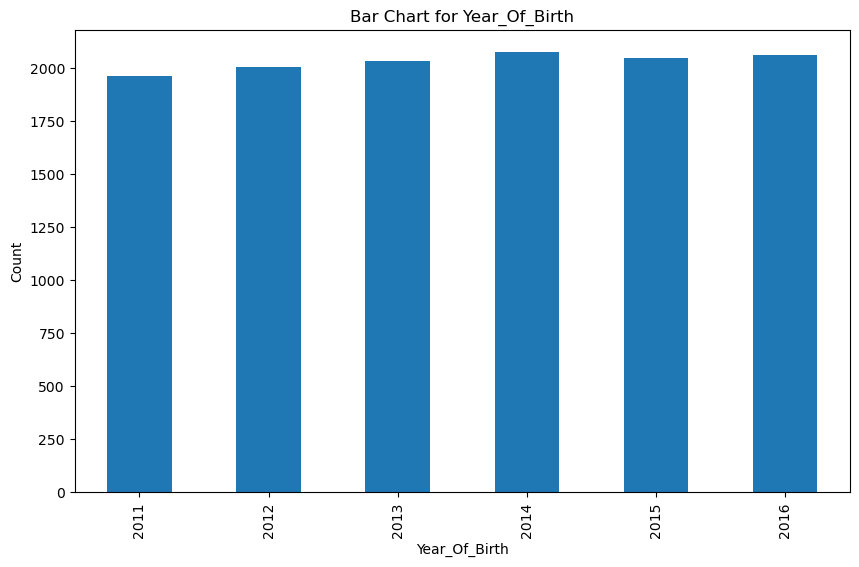

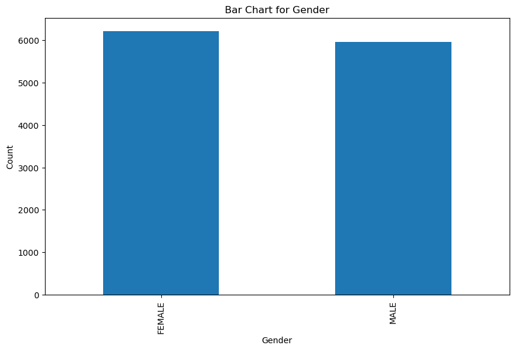

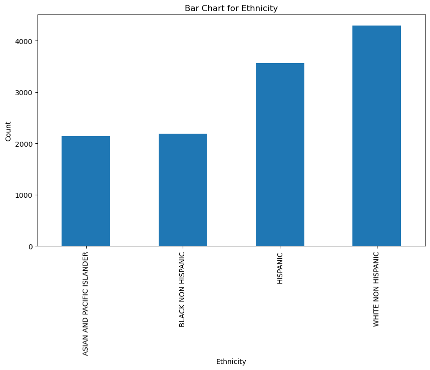

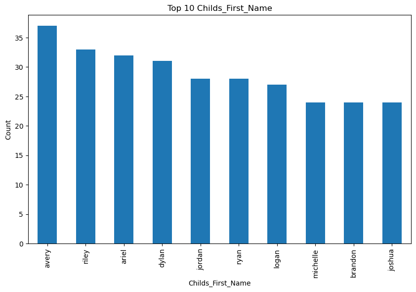

```python
import matplotlib.pyplot as mat

#Using the describe feature generates stats that calculates the count, mean, standard deviation, min,
#25th percentile, 50th percentile, 75th percentile and max. This is for Integer Data Types.

print(df_no_duplicates.describe())


#Using the BarChart feature generates stats for Object Data Types.

mat.figure(figsize=(10, 6))
df_no_duplicates['Year_Of_Birth'].value_counts().sort_index().plot(kind='bar')
mat.title('Bar Chart for Year_Of_Birth')
mat.xlabel('Year_Of_Birth')
mat.ylabel('Count')
mat.show()

mat.figure(figsize=(10, 6))
df_no_duplicates['Gender'].value_counts().sort_index().plot(kind='bar')
mat.title('Bar Chart for Gender')
mat.xlabel('Gender')
mat.ylabel('Count')
mat.show()

mat.figure(figsize=(10, 6))
df_no_duplicates['Ethnicity'].value_counts().sort_index().plot(kind='bar')
mat.title('Bar Chart for Ethnicity')
mat.xlabel('Ethnicity')
mat.ylabel('Count')
mat.show()

top = 10  # Change the number to control the number of names displayed
top_names = df_no_duplicates['Childs_First_Name'].value_counts().head(top)

mat.figure(figsize=(10, 6))
top_names.plot(kind='bar')
mat.title(f'Top {top} Childs_First_Name')
mat.xlabel('Childs_First_Name')
mat.ylabel('Count')
mat.show()
```

## Determine how many unique names are in the data. This should be the number of unique names within the entire dataset – i.e. not specific to year, gender, or ethnicity.

```python
unique_name_count = df_no_duplicates['Childs_First_Name'].nunique()
print("Number of unique names:", unique_name_count)
```

```
Number of unique names: 1775
```

## Do a multicolumn sort of Rank + Year + Gender + Ethnicity. Print the first 60 rows.

```python
multi_sort = df_no_duplicates.sort_values(by=['Rank', 'Year_Of_Birth', 'Gender', 'Ethnicity'])
print(multi_sort.head(60))
```

```
      Year_Of_Birth  Gender                   Ethnicity Childs_First_Name  \
15518          2011  FEMALE  ASIAN AND PACIFIC ISLANDER            sophia
15828          2011  FEMALE          BLACK NON HISPANIC           madison
16193          2011  FEMALE                    HISPANIC          isabella
16838          2011  FEMALE          WHITE NON HISPANIC            esther
17515          2011    MALE  ASIAN AND PACIFIC ISLANDER             ethan
17817          2011    MALE          BLACK NON HISPANIC            jayden
18214          2011    MALE                    HISPANIC            jayden
18797          2011    MALE          WHITE NON HISPANIC           michael
11663          2012  FEMALE  ASIAN AND PACIFIC ISLANDER             chloe
12013          2012  FEMALE          BLACK NON HISPANIC           madison
12343          2012  FEMALE                    HISPANIC          isabella
12928          2012  FEMALE          WHITE NON HISPANIC              emma
13640          2012    MALE  ASIAN AND PACIFIC ISLANDER              ryan
13983          2012    MALE          BLACK NON HISPANIC            jayden
```

[output cut: 108 more lines]

## Print the ten most popular (greatest count) names in descending order by total count. This should be the most popular names within the entire dataset – i.e. not specific to year, gender, or ethnicity.

```python
grouped_df = df_no_duplicates.groupby('Childs_First_Name')['Count'].sum().reset_index()
grouped_df.rename(columns={'Count': 'Total_Count'}, inplace=True)
grouped_df = grouped_df.sort_values(by='Total_Count', ascending=False)
top_10_grouped_df = grouped_df.head(10)
print(top_10_grouped_df)
```

```
     Childs_First_Name  Total_Count
581              ethan         4245
771              jacob         3994
828             jayden         3954
441             daniel         3463
1577            sophia         3431
1182           matthew         3327
1220           michael         3279
748           isabella         3243
455              david         3239
1319              noah         3231
```

## Print the ten most popular (greatest count) names for each gender, not specific to year or ethnicity in descending order by total count

```python
grouped_df = df_no_duplicates.groupby(['Childs_First_Name', 'Gender'])['Count'].sum().reset_index()
grouped_df.rename(columns={'Count': 'Total_Count'}, inplace=True)
grouped_df['Rank'] = grouped_df.groupby('Gender')['Total_Count'].rank(ascending=False, method='first')
grouped_df = grouped_df.sort_values(by=['Gender', 'Total_Count'], ascending=[True, False])
top_10_by_gender = grouped_df[grouped_df['Rank'] <= 10]
for gender, group in top_10_by_gender.groupby('Gender'):
    print(f"Top 10 names for {gender} in descending order:")
    print(group)
    print("\n")
```

```
Top 10 names for FEMALE in descending order:
     Childs_First_Name  Gender  Total_Count  Rank
1603            sophia  FEMALE         3431   1.0
757           isabella  FEMALE         3243   2.0
1351            olivia  FEMALE         3083   3.0
565               emma  FEMALE         2932   4.0
1231               mia  FEMALE         2804   5.0
564              emily  FEMALE         2518   6.0
1037              leah  FEMALE         2217   7.0
1124           madison  FEMALE         2083   8.0
241                ava  FEMALE         2074   9.0
401              chloe  FEMALE         2046  10.0


Top 10 names for MALE in descending order:
     Childs_First_Name Gender  Total_Count  Rank
590              ethan   MALE         4245   1.0
780              jacob   MALE         3994   2.0
837             jayden   MALE         3954   3.0
448             daniel   MALE         3463   4.0
1196           matthew   MALE         3327   5.0
1234           michael   MALE         3279   6.0
462              david   MALE         3239   7.0
1335              noah   MALE         3231   8.0
1064              liam   MALE         3226   9.0
47               aiden   MALE         3155  10.0
```

## Determine how many names were recorded 10 or fewer times. This should be the least popular names within the dataset – i.e. not specific to year, gender or ethnicity.

```python
name_counts = df_no_duplicates.groupby('Childs_First_Name')['Count'].sum()
least_popular_names = name_counts[name_counts <= 10]
count_of_least_popular_names = len(least_popular_names)
print("Names recorded 10 or fewer times:", count_of_least_popular_names)
```

```
Names recorded 10 or fewer times: 142
```